# Loan Prediction

### Project details:

#### Variable Description:

Loan_ID (Unique Loan ID)  
Gender (Male/ Female)  
Married (Applicant married (Y/N))  
Dependents (Number of dependents)  
Education (Applicant Education (Graduate/ Under Graduate))  
Self_Employed (Self-employed (Y/N))  
ApplicantIncome (Applicant income)  
CoapplicantIncome (Coapplicant income)  
LoanAmount (Loan amount in thousands)  
Loan_Amount_Term (Term of loan in months)  
Credit_History (Credit history meets guidelines. 1-good, 0-not good)  
Property_Area (Urban/ Semi Urban/ Rural)  
Loan_Status (Loan approved (Y/N))

#### Objective:

This project asks you to determine whether a loan will get approved or not. Also, try to find good insights with a financial management perspective.

```r
library(tidyr)
library(dplyr)
library(ggplot2)
library(caret)
```

### Loading the data

```r
loan_train <- read.csv('train_u6lujuX_CVtuZ9i.csv',na.strings = c('NA',''))
summary(loan_train)
```

```
##      Loan_ID       Gender    Married    Dependents        Education
##  LP001002:  1   Female:112   No  :213   0   :345   Graduate    :480
##  LP001003:  1   Male  :489   Yes :398   1   :102   Not Graduate:134
##  LP001005:  1   NA's  : 13   NA's:  3   2   :101
##  LP001006:  1                           3+  : 51
##  LP001008:  1                           NA's: 15
##  LP001011:  1
##  (Other) :608
##  Self_Employed ApplicantIncome CoapplicantIncome   LoanAmount
##  No  :500      Min.   :  150   Min.   :    0     Min.   :  9.0
##  Yes : 82      1st Qu.: 2878   1st Qu.:    0     1st Qu.:100.0
##  NA's: 32      Median : 3812   Median : 1188     Median :128.0
##                Mean   : 5403   Mean   : 1621     Mean   :146.4
##                3rd Qu.: 5795   3rd Qu.: 2297     3rd Qu.:168.0
##                Max.   :81000   Max.   :41667     Max.   :700.0
##                                                  NA's   :22
##  Loan_Amount_Term Credit_History     Property_Area Loan_Status
##  Min.   : 12      Min.   :0.0000   Rural    :179   N:192
##  1st Qu.:360      1st Qu.:1.0000   Semiurban:233   Y:422
##  Median :360      Median :1.0000   Urban    :202
##  Mean   :342      Mean   :0.8422
##  3rd Qu.:360      3rd Qu.:1.0000
##  Max.   :480      Max.   :1.0000
##  NA's   :14       NA's   :50
```

```r
glimpse(loan_train)
```

```
## Observations: 614
## Variables: 13
## $ Loan_ID           <fctr> LP001002, LP001003, LP001005, LP001006, LP0...
## $ Gender            <fctr> Male, Male, Male, Male, Male, Male, Male, M...
## $ Married           <fctr> No, Yes, Yes, Yes, No, Yes, Yes, Yes, Yes, ...
## $ Dependents        <fctr> 0, 1, 0, 0, 0, 2, 0, 3+, 2, 1, 2, 2, 2, 0, ...
## $ Education         <fctr> Graduate, Graduate, Graduate, Not Graduate,...
## $ Self_Employed     <fctr> No, No, Yes, No, No, Yes, No, No, No, No, N...
## $ ApplicantIncome   <int> 5849, 4583, 3000, 2583, 6000, 5417, 2333, 30...
## $ CoapplicantIncome <dbl> 0, 1508, 0, 2358, 0, 4196, 1516, 2504, 1526,...
## $ LoanAmount        <int> NA, 128, 66, 120, 141, 267, 95, 158, 168, 34...
## $ Loan_Amount_Term  <int> 360, 360, 360, 360, 360, 360, 360, 360, 360,...
## $ Credit_History    <int> 1, 1, 1, 1, 1, 1, 1, 0, 1, 1, 1, 1, 1, 1, 1,...
## $ Property_Area     <fctr> Urban, Rural, Urban, Urban, Urban, Urban, U...
## $ Loan_Status       <fctr> Y, N, Y, Y, Y, Y, Y, N, Y, N, Y, Y, Y, N, Y...
```

```r
#removing loan_ID
loan_train <- loan_train[-1]
#making the variables as factor
loan_train$Credit_History <- as.factor(loan_train$Credit_History)
loan_train$Loan_Amount_Term <- as.factor(loan_train$Loan_Amount_Term)
```

Can find the missing values in:

- gender (13)
- married (3)
- dependents (15)
- self-employed (32)
- loan amount (22)
- loan amount term (14)
- credit history (50)

### Finding columns and rows with missing values using function

```r
miss <- function(x) {
 cat('\nThe columns having missing values are:')
 for(i in 1:ncol(x)) {
  if(length(x[i][is.na(x[i])]) > 0) {
    cat('\n',names(x[i]),':',length(x[i][is.na(x[i])]))
  }
 }
  cat('\n\nThe number of rows with missing values are:',nrow(x)-nrow(na.omit(x)))
  cat('\nThe proportion of missing values is:',signif((nrow(x)-nrow(na.omit(x)))/nrow(x),2))
}

miss(loan_train)
```

```
##
## The columns having missing values are:
##  Gender : 13
##  Married : 3
##  Dependents : 15
##  Self_Employed : 32
##  LoanAmount : 22
##  Loan_Amount_Term : 14
##  Credit_History : 50
##
## The number of rows with missing values are: 134
## The proportion of missing values is: 0.22
```

### For numerical data, weighted average is used. The data points that are near are weighted more than far away data points.

### For Categorical data, mode is used

```r
library(VIM)     #for kNN
library(laeken)  #for weightedMean

loan_train1 <- kNN(loan_train,variable=c('Gender','Married','Dependents','Self_Employed','LoanAmount','Loan_Amount_Term','Credit_History'),k=23,numFun = weightedMean,weightDist=TRUE)

summary(loan_train1)
```

```
##     Gender    Married   Dependents        Education   Self_Employed
##  Female:114   No :215   0 :357     Graduate    :480   No :532
##  Male  :500   Yes:399   1 :102     Not Graduate:134   Yes: 82
##                         2 :104
##                         3+: 51
##
##
##
##  ApplicantIncome CoapplicantIncome   LoanAmount    Loan_Amount_Term
##  Min.   :  150   Min.   :    0     Min.   :  9.0   360    :526
##  1st Qu.: 2878   1st Qu.:    0     1st Qu.:100.0   180    : 44
##  Median : 3812   Median : 1188     Median :128.0   480    : 15
##  Mean   : 5403   Mean   : 1621     Mean   :146.1   300    : 13
##  3rd Qu.: 5795   3rd Qu.: 2297     3rd Qu.:166.8   84     :  4
##  Max.   :81000   Max.   :41667     Max.   :700.0   240    :  4
##                                                    (Other):  8
##  Credit_History   Property_Area Loan_Status Gender_imp
##  0: 89          Rural    :179   N:192       Mode :logical
##  1:525          Semiurban:233   Y:422       FALSE:601
##                 Urban    :202               TRUE :13
##                                             NA's :0
##
##
##
##  Married_imp     Dependents_imp  Self_Employed_imp LoanAmount_imp
##  Mode :logical   Mode :logical   Mode :logical     Mode :logical
##  FALSE:611       FALSE:599       FALSE:582         FALSE:592
##  TRUE :3         TRUE :15        TRUE :32          TRUE :22
##  NA's :0         NA's :0         NA's :0           NA's :0
##
##
##
##  Loan_Amount_Term_imp Credit_History_imp
##  Mode :logical        Mode :logical
##  FALSE:600            FALSE:564
##  TRUE :14             TRUE :50
##  NA's :0              NA's :0
##
##
##
```

```r
glimpse(loan_train1)
```

```
## Observations: 614
## Variables: 19
## $ Gender               <fctr> Male, Male, Male, Male, Male, Male, Male...
## $ Married              <fctr> No, Yes, Yes, Yes, No, Yes, Yes, Yes, Ye...
## $ Dependents           <fctr> 0, 1, 0, 0, 0, 2, 0, 3+, 2, 1, 2, 2, 2, ...
## $ Education            <fctr> Graduate, Graduate, Graduate, Not Gradua...
## $ Self_Employed        <fctr> No, No, Yes, No, No, Yes, No, No, No, No...
## $ ApplicantIncome      <int> 5849, 4583, 3000, 2583, 6000, 5417, 2333,...
## $ CoapplicantIncome    <dbl> 0, 1508, 0, 2358, 0, 4196, 1516, 2504, 15...
## $ LoanAmount           <int> 111, 128, 66, 120, 141, 267, 95, 158, 168...
## $ Loan_Amount_Term     <fctr> 360, 360, 360, 360, 360, 360, 360, 360, ...
## $ Credit_History       <fctr> 1, 1, 1, 1, 1, 1, 1, 0, 1, 1, 1, 1, 1, 1...
## $ Property_Area        <fctr> Urban, Rural, Urban, Urban, Urban, Urban...
## $ Loan_Status          <fctr> Y, N, Y, Y, Y, Y, Y, N, Y, N, Y, Y, Y, N...
## $ Gender_imp           <lgl> FALSE, FALSE, FALSE, FALSE, FALSE, FALSE,...
## $ Married_imp          <lgl> FALSE, FALSE, FALSE, FALSE, FALSE, FALSE,...
## $ Dependents_imp       <lgl> FALSE, FALSE, FALSE, FALSE, FALSE, FALSE,...
## $ Self_Employed_imp    <lgl> FALSE, FALSE, FALSE, FALSE, FALSE, FALSE,...
## $ LoanAmount_imp       <lgl> TRUE, FALSE, FALSE, FALSE, FALSE, FALSE, ...
## $ Loan_Amount_Term_imp <lgl> FALSE, FALSE, FALSE, FALSE, FALSE, FALSE,...
## $ Credit_History_imp   <lgl> FALSE, FALSE, FALSE, FALSE, FALSE, FALSE,...
```

### Remove the extra columns created by kNN imputation.

### Validate any missing values are present

```r
loan_train1 <- loan_train1[-c(13:19)]
miss(loan_train1)
```

```
##
## The columns having missing values are:
##
## The number of rows with missing values are: 0
## The proportion of missing values is: 0
```

### Data Visualization (Univariate analysis)

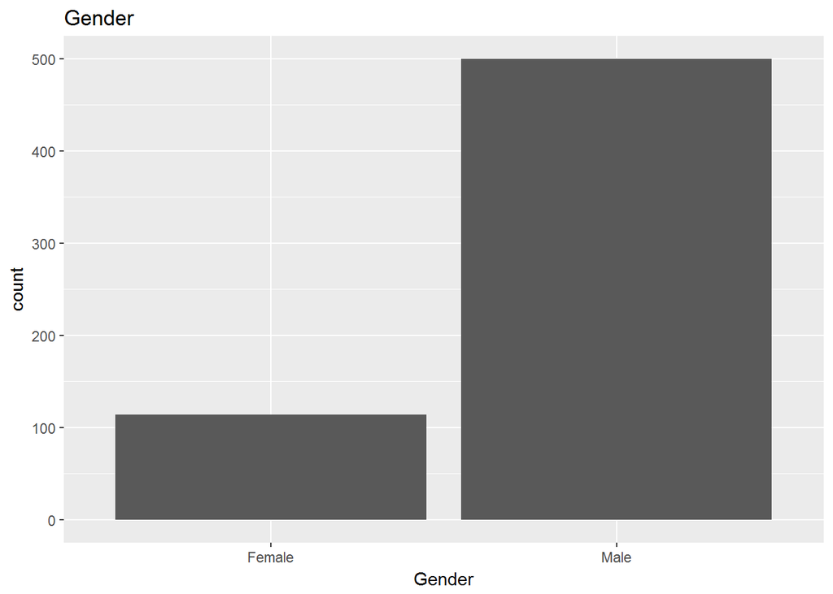

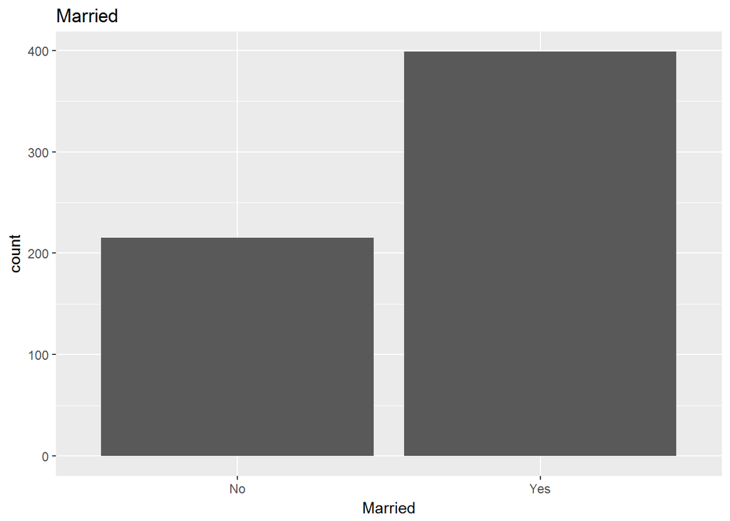

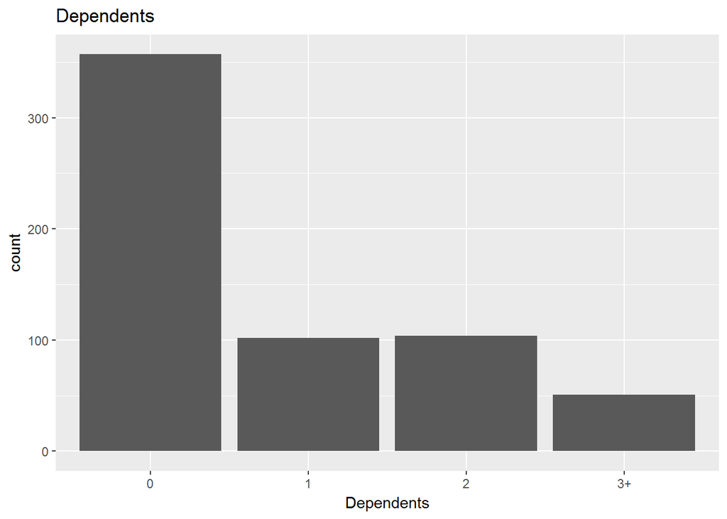

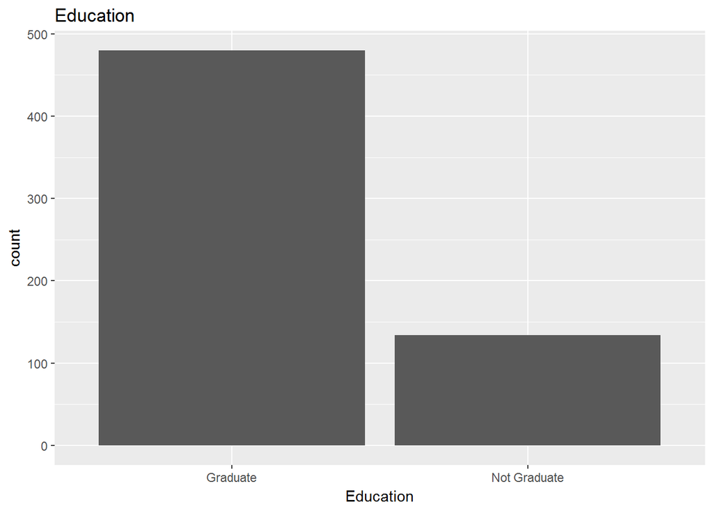

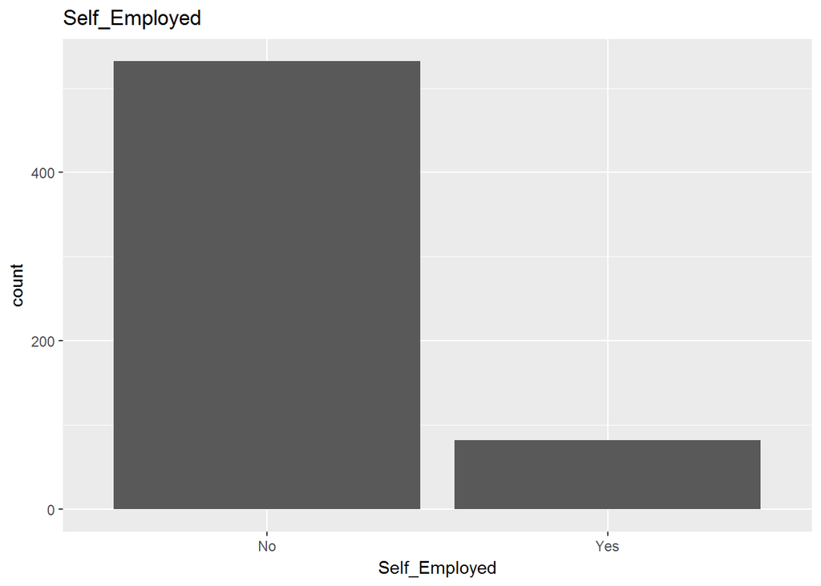

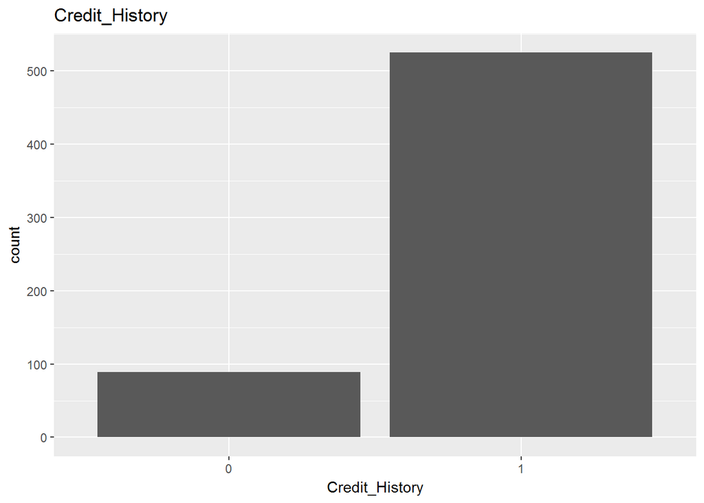

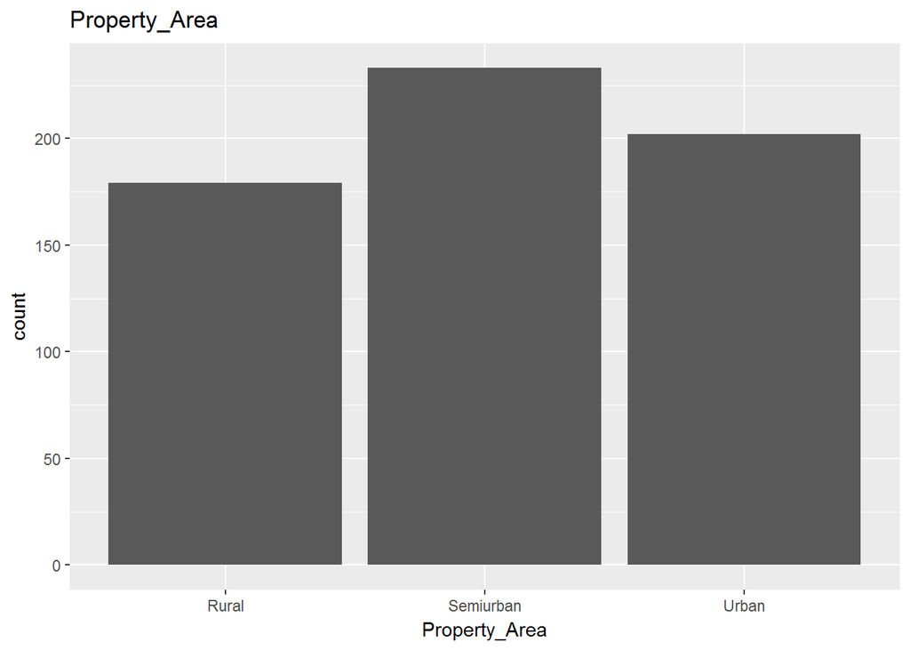

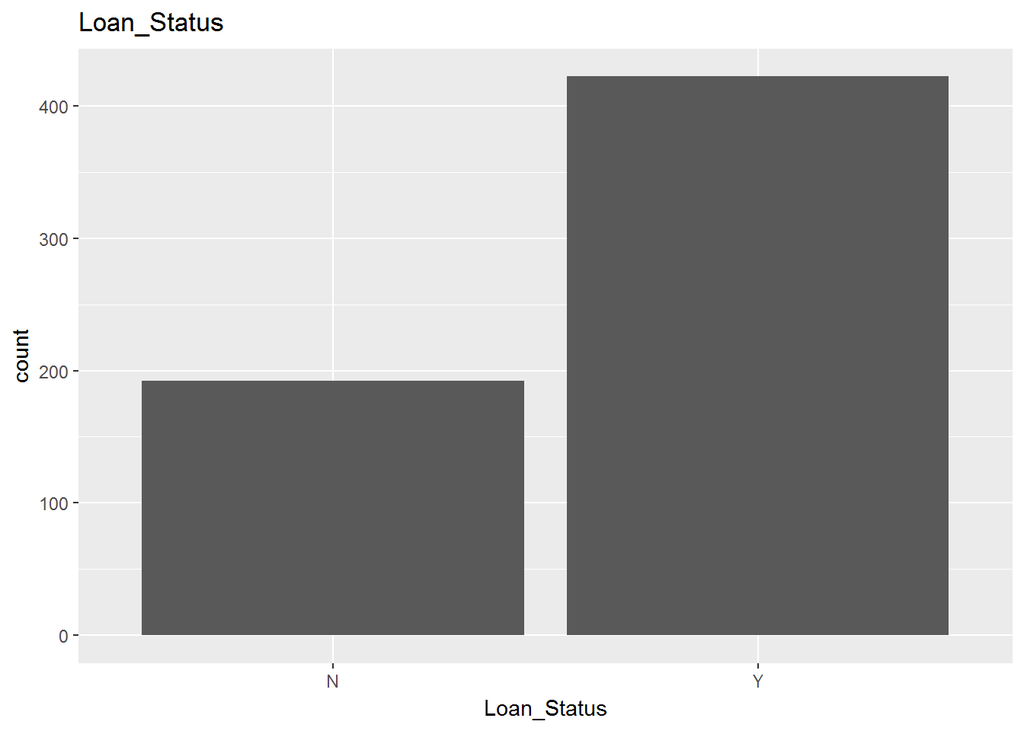

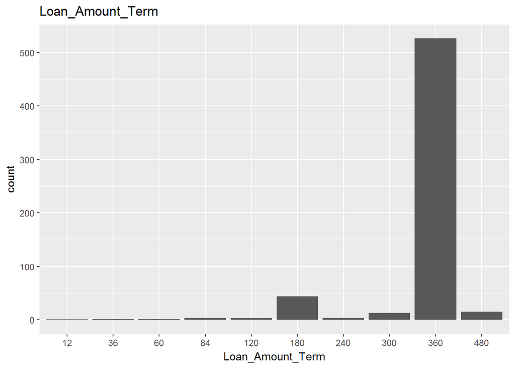

```r
cols <- c('Gender', 'Married', 'Dependents', 'Education', 'Self_Employed', 'Credit_History', 'Property_Area', 'Loan_Status','Loan_Amount_Term')
for (i in 1:length(cols))
{
  pl <- ggplot(loan_train1,aes(x=loan_train1[,cols[i]]))+geom_bar()+labs(x=cols[i],title=cols[i])
  print(pl)
}
```

Can infer that:

- There are more male customers who applied for loan
- There are more married customers
- There are more number of customers with 0 dependents. 3+ dependents are very less
- There are more graduates who applied for loan
- There are less customers having occupation as self employed
- There are more customers with credit history of 1
- There are more customers who applied loan for semi-urban and urban areas
- There are more customers whose loans are approved
- There are many customers who applied for loan term as 360 months

### Data Visualization (Bivariate analysis)

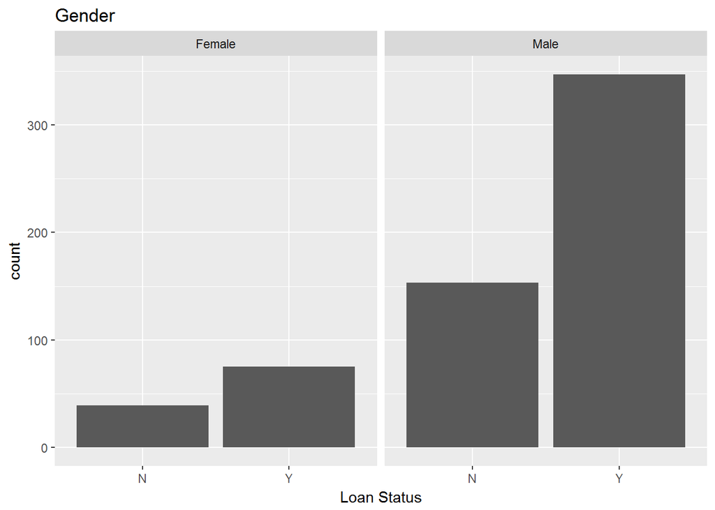

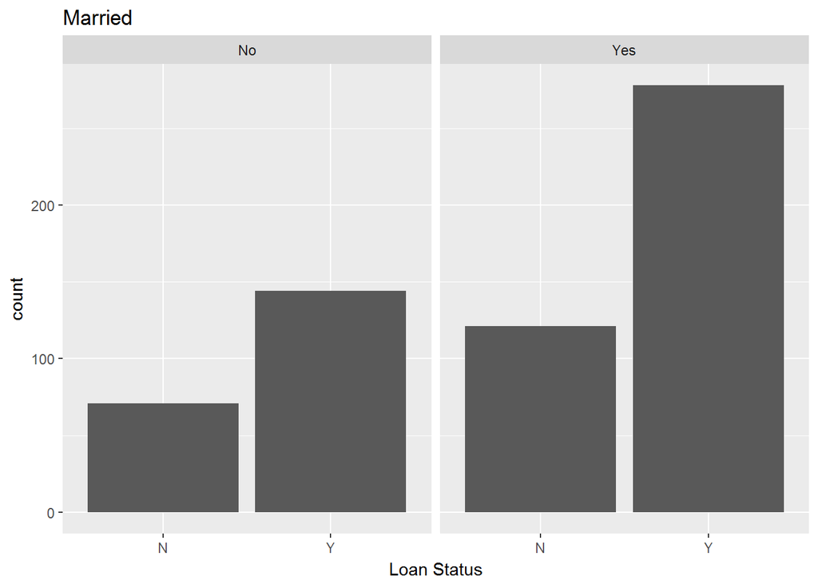

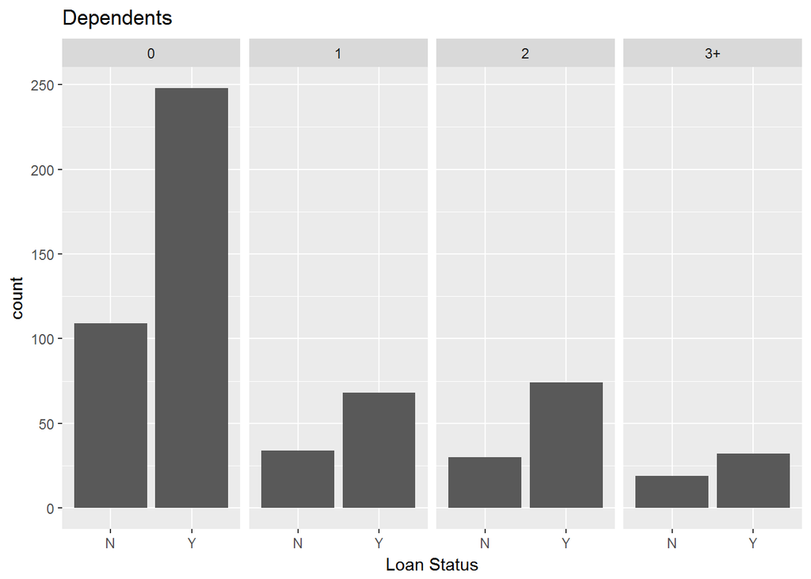

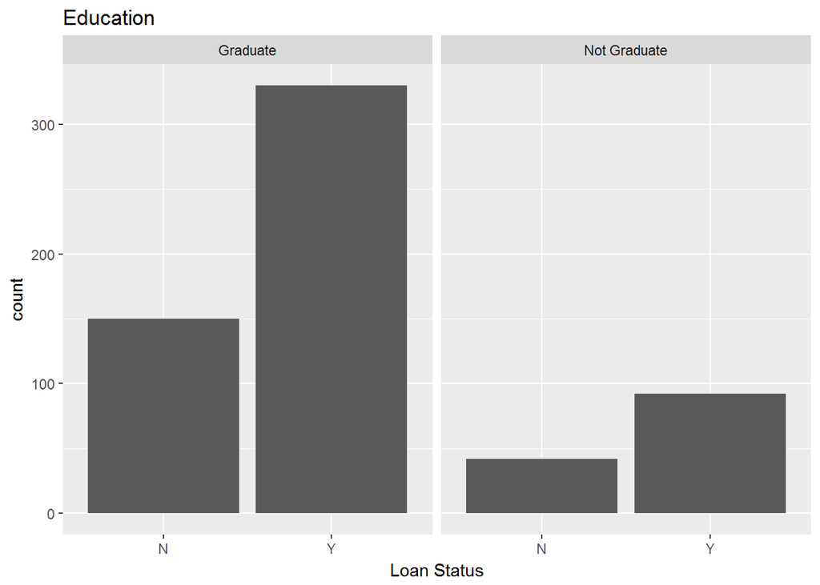

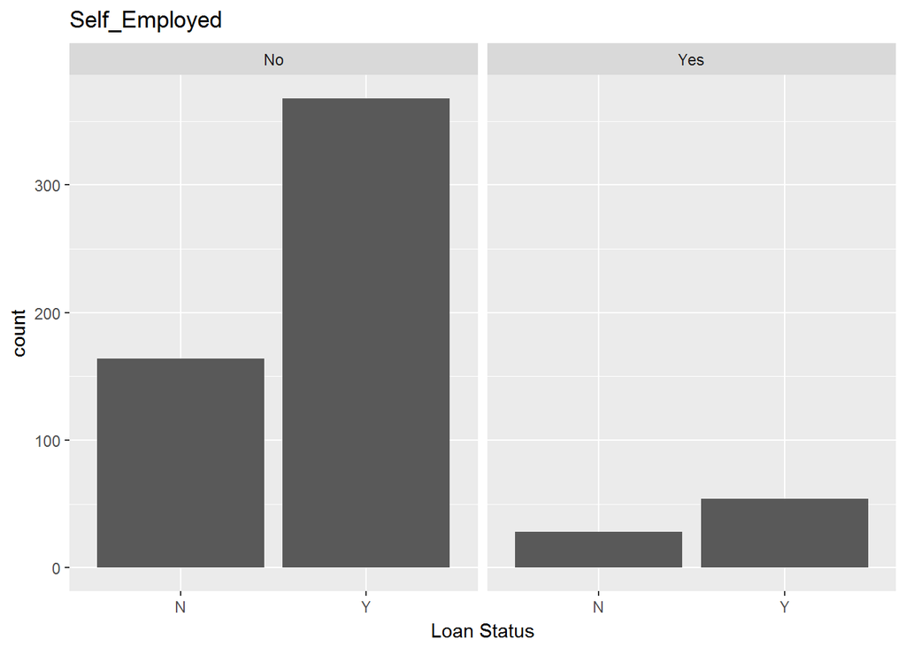

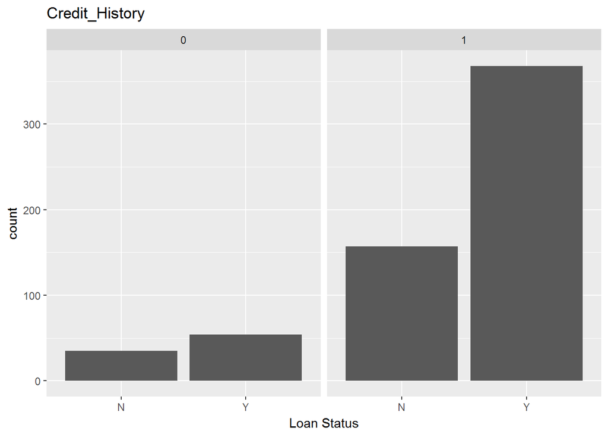

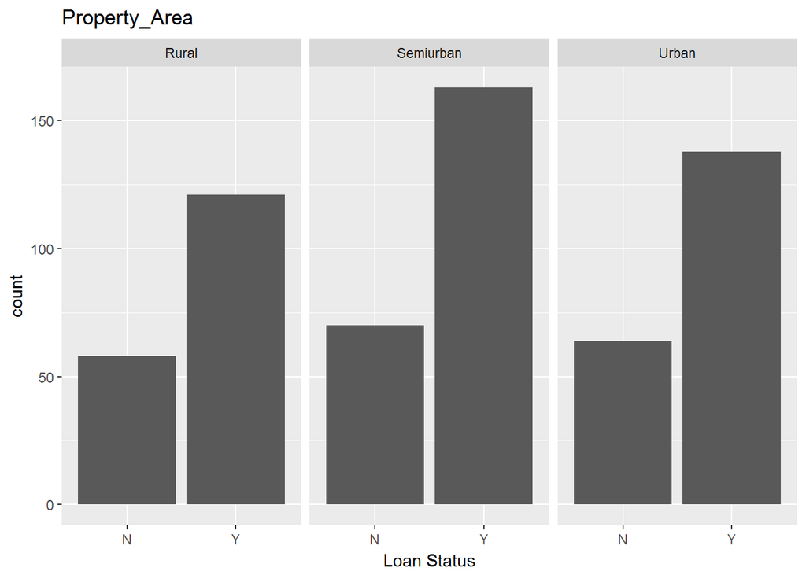

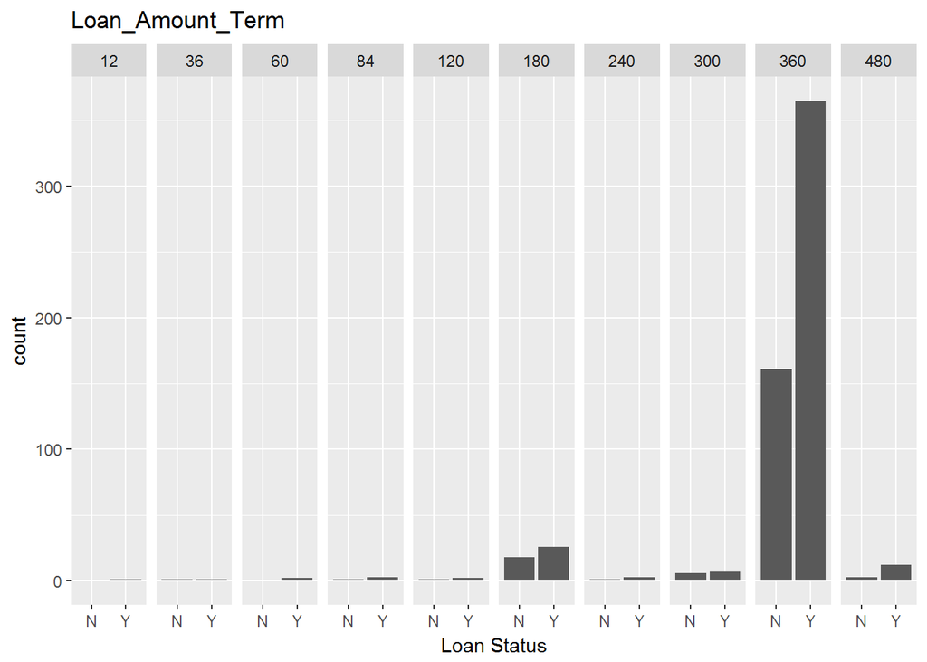

```r
cols <- c('Gender', 'Married', 'Dependents', 'Education', 'Self_Employed', 'Credit_History', 'Property_Area', 'Loan_Amount_Term')
for (i in 1:length(cols))
{
  pl <- ggplot(loan_train1,aes(loan_train1$Loan_Status))+geom_bar()+facet_grid(~loan_train1[,cols[i]])+labs(x='Loan Status',title=cols[i])
  print(pl)

}
```

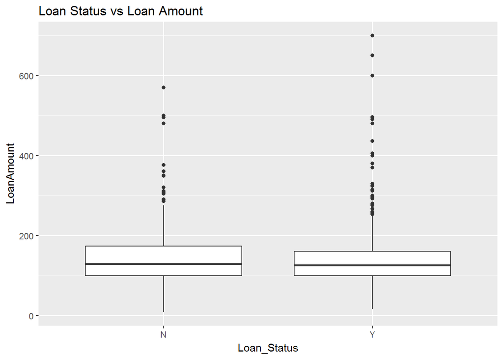

```r
ggplot(data=loan_train1,aes(Loan_Status,LoanAmount))+geom_boxplot()+labs(title='Loan Status vs Loan Amount')
```

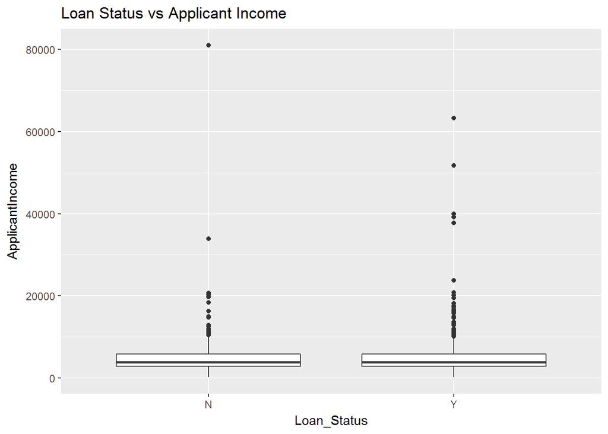

```r
ggplot(data=loan_train1,aes(Loan_Status,ApplicantIncome))+geom_boxplot()+labs(title='Loan Status vs Applicant Income')
```

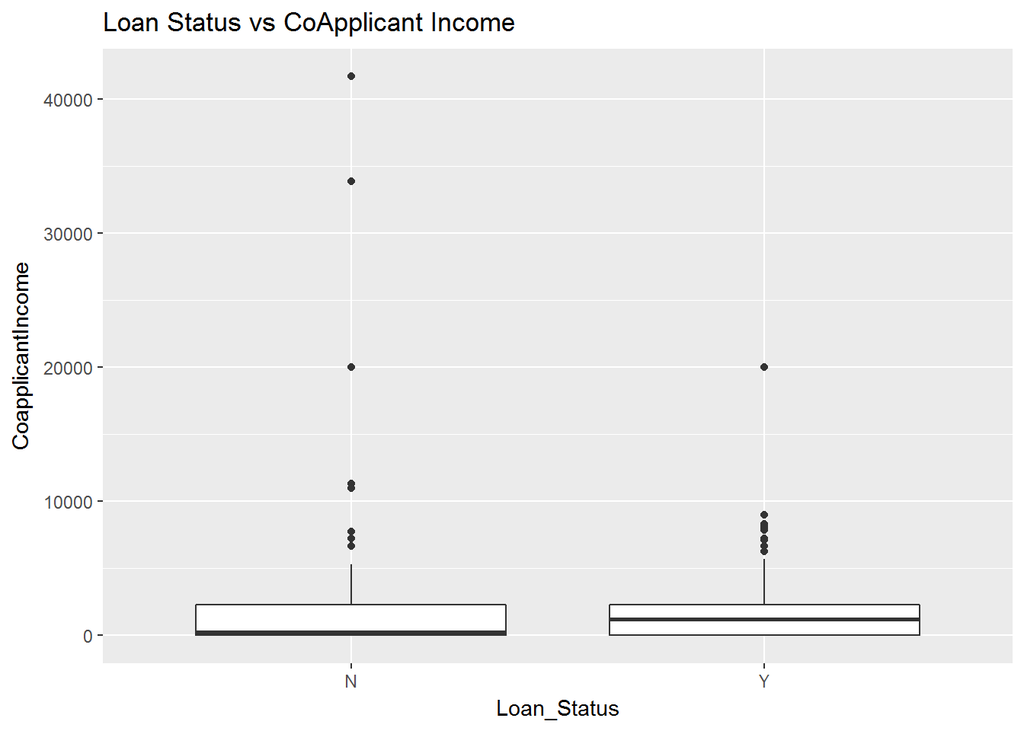

```r
ggplot(data=loan_train1,aes(Loan_Status,CoapplicantIncome))+geom_boxplot()+labs(title='Loan Status vs CoApplicant Income')
```

Can infer that:

- More approvals for males (as proportion is high, otherwise not much difference)
- More approvals for married customers (as proportion is high, otherwise not much difference)
- More approvals for 0 dependents (as proportion is high, otherwise not much difference)
- More approvals for graduates (as proportion is high, otherwise not much difference)
- Less approvals for self-employed (as proportion is low, otherwise not much difference)
- More approvals for credit history of 1 (as proportion is high, otherwise not much difference)
- More approvals for semi-urban and urban areas (as proportion is high, otherwise not much difference)
- More approvals for loan term as 360 months (as proportion is high, otherwise not much difference)
- The loans that got approved are the ones that took less loan amount compared to that of rejected
- Applicant income doesn’t seem different for approved/rejected loans
- Coapplicant income doesn’t seem different for approved/rejected loans

### Data Visualization (Multivariate analysis)

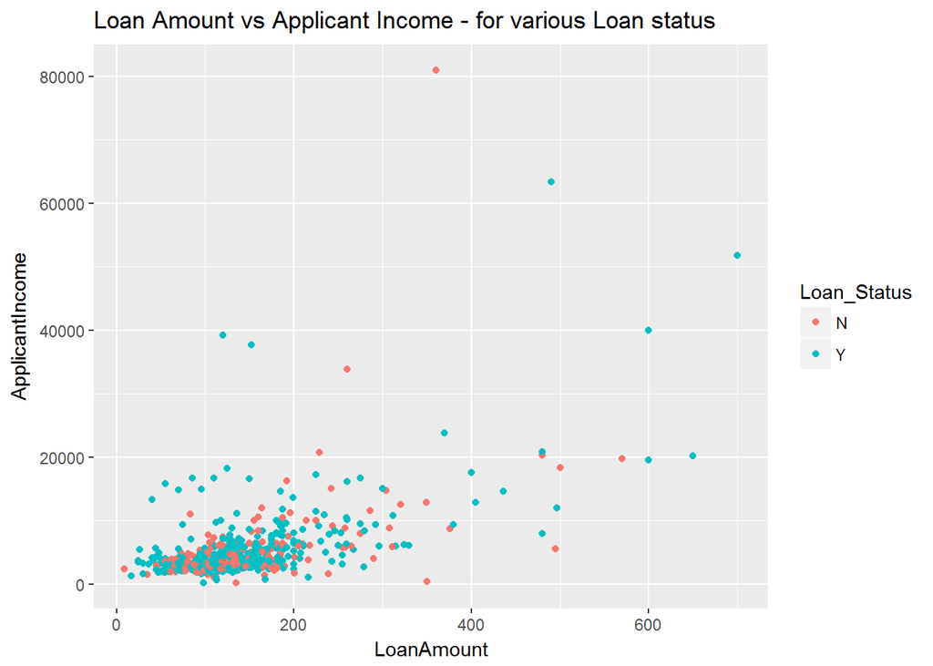

```r
ggplot(data=loan_train1,aes(LoanAmount,ApplicantIncome,color=Loan_Status))+geom_point()+labs(title='Loan Amount vs Applicant Income - for various Loan status')
```

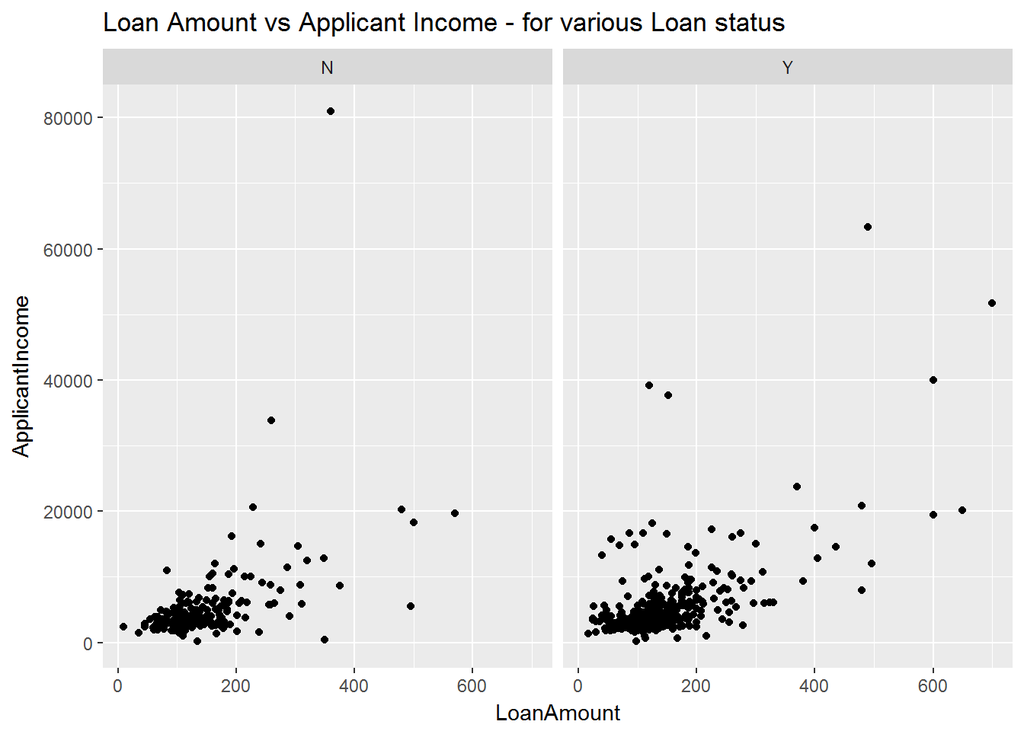

```r
ggplot(data=loan_train1,aes(LoanAmount,ApplicantIncome))+geom_point()+facet_wrap(~Loan_Status)+labs(title='Loan Amount vs Applicant Income - for various Loan status')
```

Can infer that:

- As applicant income increases, loan amount increases. The rejected cases are mostly the ones with more loan amount and lesser applicant income (though there are lots of outliers)

### Spliting training set into two parts based on outcome: 75% and 25%

```r
set.seed(100)
index <- createDataPartition(loan_train1$Loan_Status, p=0.75, list=FALSE)
trainSet <- loan_train1[ index,]
testSet <- loan_train1[-index,]
```

### Defining the training controls for multiple models

```r
#using 10-fold cross validation
fitControl <- trainControl(
  method = "cv",
  number = 10,
  savePredictions = 'final',
  classProbs = T)
```

### Defining the predictors and outcome

```r
predictors<-c("Credit_History", "LoanAmount", "Loan_Amount_Term", "ApplicantIncome",
  "CoapplicantIncome","Property_Area","Gender","Married","Dependents","Education","Self_Employed")


outcomeName<-'Loan_Status'
```

### Initializing the table

```r
prediction <<- data.frame()
```

### Normalising the data

```r
trainSet1 <- trainSet

#converting non-numeric(factor) data to numeric
trainSet1[,c(1:5,9,10,11)] <- sapply(trainSet1[,c(1:5,9,10,11)], function(x) as.numeric(x))



#normalise appl income,co-appl income,loan amount, loan amount term
trainSet1[,c(6:9)] <- scale(trainSet1[,c(6:9)],center=TRUE,scale=TRUE)
#trainSet1[,c(6:9)] <- sapply(trainSet1[,c(6:9)], function(x) ifelse(x==0,0,log(x)))


testSet1 <- testSet

#converting non-numeric(factor) data to numeric
testSet1[,c(1:5,9,10,11)] <- sapply(testSet1[,c(1:5,9,10,11)], function(x) as.numeric(x))



#normalise appl income,co-appl income,loan amount, loan amount term
testSet1[,c(6:9)] <- scale(testSet1[,c(6:9)],center=TRUE,scale=TRUE)
#testSet1[,c(6:9)] <- sapply(testSet1[,c(6:9)], function(x) ifelse(x==0,0,log(x)))
```

### Logistic regression

```r
#Training the logistic regression model

set.seed(101)
model_lr<-train(trainSet1[,predictors],trainSet1[,outcomeName],method='glm',trControl=fitControl)
model_lr
```

```
## Generalized Linear Model
##
## 461 samples
##  11 predictor
##   2 classes: 'N', 'Y'
##
## No pre-processing
## Resampling: Cross-Validated (10 fold)
## Summary of sample sizes: 414, 415, 416, 414, 414, 415, ...
## Resampling results:
##
##   Accuracy   Kappa
##   0.8027423  0.458721
##
##
```

```r
#Predicting using logistic regression model
predict_model_lr<-predict(model_lr,testSet1[,predictors])

#Checking the accuracy of the logistic regression model
c1 <- confusionMatrix(predict_model_lr,testSet1[,outcomeName],positive = 'Y')

temp1 <- cbind(Accuracy=c1$overall[['Accuracy']],Sensitivity=c1$byClass[['Sensitivity']],Specificity=c1$byClass[['Specificity']],Precision=c1$byClass[['Precision']])

prediction <<- prediction[-1,]
prediction <<- rbind(prediction, log_reg=temp1 )
prediction['log_reg',]
```

```
##          Accuracy Sensitivity Specificity Precision
## log_reg 0.8300654   0.9809524         0.5 0.8110236
```

Can infer that:

- Accuracy is 0.83

```r
#Training the random forest model

set.seed(101)
model_rf<-train(trainSet1[,predictors],trainSet1[,outcomeName],method='rf',trControl=fitControl)
model_rf
```

```
## Random Forest
##
## 461 samples
##  11 predictor
##   2 classes: 'N', 'Y'
##
## No pre-processing
## Resampling: Cross-Validated (10 fold)
## Summary of sample sizes: 414, 415, 416, 414, 414, 415, ...
## Resampling results across tuning parameters:
##
##   mtry  Accuracy   Kappa
##    2    0.7918224  0.4352629
##    6    0.7658721  0.3871666
##   11    0.7636037  0.3875057
##
## Accuracy was used to select the optimal model using  the largest value.
## The final value used for the model was mtry = 2.
```

```r
#Predicting using random forest model
predict_model_rf<-predict(model_rf,testSet1[,predictors])

#Checking the accuracy of the random forest model
c1 <- confusionMatrix(predict_model_rf,testSet1[,outcomeName],positive = 'Y')

temp1 <- cbind(Accuracy=c1$overall[['Accuracy']],Sensitivity=c1$byClass[['Sensitivity']],Specificity=c1$byClass[['Specificity']],Precision=c1$byClass[['Precision']])

prediction <<- prediction[-2,]
prediction <<- rbind(prediction, random_forest=temp1 )
prediction['random_forest',]
```

```
##                Accuracy Sensitivity Specificity Precision
## random_forest 0.8235294   0.9428571      0.5625     0.825
```

Can infer that:

- The optimal value of mtry choosen is 2
- Accuracy is 0.8235

```r
#Training the knn model

set.seed(101)



model_knn<-train(trainSet1[,predictors],trainSet1[,outcomeName],method='knn',trControl=fitControl)
model_knn
```

```
## k-Nearest Neighbors
##
## 461 samples
##  11 predictor
##   2 classes: 'N', 'Y'
##
## No pre-processing
## Resampling: Cross-Validated (10 fold)
## Summary of sample sizes: 414, 415, 416, 414, 414, 415, ...
## Resampling results across tuning parameters:
##
##   k  Accuracy   Kappa
##   5  0.7352883  0.2756597
##   7  0.7114616  0.1744025
##   9  0.7157673  0.1683956
##
## Accuracy was used to select the optimal model using  the largest value.
## The final value used for the model was k = 5.
```

```r
#Predicting using knn model
predict_model_knn <- predict(model_knn,testSet1[,predictors])

#Checking the accuracy of the knn model
c1 <- confusionMatrix(predict_model_knn,testSet1[,outcomeName],positive = 'Y')


temp1 <- cbind(Accuracy=c1$overall[['Accuracy']],Sensitivity=c1$byClass[['Sensitivity']],Specificity=c1$byClass[['Specificity']],Precision=c1$byClass[['Precision']])

prediction <<- prediction[-3,]
prediction <<- rbind(prediction, k_nearest=temp1 )
prediction['k_nearest',]
```

```
##            Accuracy Sensitivity Specificity Precision
## k_nearest 0.7124183   0.8761905   0.3541667 0.7479675
```

Can infer that:

- The optimal number of neighbours choosen is 5
- Accuracy is 0.7124

```r
#Training the rpart model/decision tree

set.seed(101)
model_rpart<-train(trainSet1[,predictors],trainSet1[,outcomeName],method='rpart',trControl=fitControl)
model_rpart
```

```
## CART
##
## 461 samples
##  11 predictor
##   2 classes: 'N', 'Y'
##
## No pre-processing
## Resampling: Cross-Validated (10 fold)
## Summary of sample sizes: 414, 415, 416, 414, 414, 415, ...
## Resampling results across tuning parameters:
##
##   cp           Accuracy   Kappa
##   0.006944444  0.7723456  0.3999315
##   0.008333333  0.7789156  0.4105158
##   0.368055556  0.7565567  0.2831826
##
## Accuracy was used to select the optimal model using  the largest value.
## The final value used for the model was cp = 0.008333333.
```

```r
#Predicting using rpart model
predict_model_rpart<-predict(model_rpart,testSet1[,predictors])

#Checking the accuracy of the rpart model
c1 <- confusionMatrix(predict_model_rpart,testSet1[,outcomeName],positive = 'Y')


temp1 <- cbind(Accuracy=c1$overall[['Accuracy']],Sensitivity=c1$byClass[['Sensitivity']],Specificity=c1$byClass[['Specificity']],Precision=c1$byClass[['Precision']])

prediction <<- prediction[-4,]
prediction <<- rbind(prediction, decision_tree=temp1 )
prediction['decision_tree',]
```

```
##                Accuracy Sensitivity Specificity Precision
## decision_tree 0.8300654   0.9809524         0.5 0.8110236
```

Can infer that:

- The optimal value of complexity paramter(CP) choosen is 0.0083
- The complexity parameter (cp) is used to control the size of the decision tree and to select the optimal tree size. If the cost of adding another variable to the decision tree from the current node is above the value of cp, then tree building does not continue
- Accuracy is 0.83

```r
#Training the naive bayes model

set.seed(101)
model_nb<-train(trainSet1[,predictors],trainSet1[,outcomeName],method='nb',trControl=fitControl)
model_nb
```

```
## Naive Bayes
##
## 461 samples
##  11 predictor
##   2 classes: 'N', 'Y'
##
## No pre-processing
## Resampling: Cross-Validated (10 fold)
## Summary of sample sizes: 414, 415, 416, 414, 414, 415, ...
## Resampling results across tuning parameters:
##
##   usekernel  Accuracy   Kappa
##   FALSE      0.7853490  0.42599671
##    TRUE      0.6986052  0.07437516
##
## Tuning parameter 'fL' was held constant at a value of 0
## Tuning
##  parameter 'adjust' was held constant at a value of 1
## Accuracy was used to select the optimal model using  the largest value.
## The final values used for the model were fL = 0, usekernel = FALSE
##  and adjust = 1.
```

```r
#Predicting using naive bayes model
predict_model_nb<-predict(model_nb,testSet1[,predictors])
#Checking the accuracy of the naive bayes model
c1 <- confusionMatrix(predict_model_nb,testSet1[,outcomeName],positive = 'Y')

temp1 <- cbind(Accuracy=c1$overall[['Accuracy']],Sensitivity=c1$byClass[['Sensitivity']],Specificity=c1$byClass[['Specificity']],Precision=c1$byClass[['Precision']])

prediction <<- prediction[-5,]
prediction <<- rbind(prediction, naive_bayes=temp1 )
prediction['naive_bayes',]
```

```
##              Accuracy Sensitivity Specificity Precision
## naive_bayes 0.7973856   0.9142857   0.5416667 0.8135593
```

Can infer that:

- The optimal value of kernel is FALSE
- Accuracy is 0.7973

```r
#Training the svm model

set.seed(101)
model_svm <- train(trainSet1[,predictors],trainSet1[,outcomeName],method='svmRadial',trControl=fitControl)
model_svm
```

```
## Support Vector Machines with Radial Basis Function Kernel
##
## 461 samples
##  11 predictor
##   2 classes: 'N', 'Y'
##
## No pre-processing
## Resampling: Cross-Validated (10 fold)
## Summary of sample sizes: 414, 415, 416, 414, 414, 415, ...
## Resampling results across tuning parameters:
##
##   C     Accuracy   Kappa
##   0.25  0.8006167  0.4513029
##   0.50  0.7984891  0.4445613
##   1.00  0.7918707  0.4381304
##
## Tuning parameter 'sigma' was held constant at a value of 0.09549228
## Accuracy was used to select the optimal model using  the largest value.
## The final values used for the model were sigma = 0.09549228 and C = 0.25.
```

```r
#Predicting using svm model
predict_model_svm<-predict(model_svm,testSet1[,predictors])

#Checking the accuracy of the svm model
c1 <- confusionMatrix(predict_model_svm,testSet1[,outcomeName],positive = 'Y')


temp1 <- cbind(Accuracy=c1$overall[['Accuracy']],Sensitivity=c1$byClass[['Sensitivity']],Specificity=c1$byClass[['Specificity']],Precision=c1$byClass[['Precision']])

prediction <<- prediction[-6,]
prediction <<- rbind(prediction, svm=temp1 )
prediction['svm',]
```

```
##      Accuracy Sensitivity Specificity Precision
## svm 0.8300654   0.9809524         0.5 0.8110236
```

Can infer that:

- The cost used was 0.25
- Accuracy is 0.83

### Accucuracies of all models (after testing)

```r
prediction
```

```
##                Accuracy Sensitivity Specificity Precision
## log_reg       0.8300654   0.9809524   0.5000000 0.8110236
## random_forest 0.8235294   0.9428571   0.5625000 0.8250000
## k_nearest     0.7124183   0.8761905   0.3541667 0.7479675
## decision_tree 0.8300654   0.9809524   0.5000000 0.8110236
## naive_bayes   0.7973856   0.9142857   0.5416667 0.8135593
## svm           0.8300654   0.9809524   0.5000000 0.8110236
```

### Check correlation of models(on training) before trying ensembling

```r
results <- resamples(list(glm = model_lr, rf = model_rf, knn = model_knn, rpart = model_rpart, nb = model_nb, svm = model_svm))
summary(results)
```

```
##
## Call:
## summary.resamples(object = results)
##
## Models: glm, rf, knn, rpart, nb, svm
## Number of resamples: 10
##
## Accuracy
##         Min. 1st Qu. Median   Mean 3rd Qu.   Max. NA's
## glm   0.7174  0.7915 0.8043 0.8027  0.8188 0.8696    0
## rf    0.7174  0.7801 0.8043 0.7918  0.8075 0.8261    0
## knn   0.6809  0.7011 0.7283 0.7353  0.7748 0.7872    0
## rpart 0.7174  0.7689 0.7936 0.7789  0.8043 0.8043    0
## nb    0.7174  0.7621 0.7743 0.7853  0.8167 0.8696    0
## svm   0.7391  0.7872 0.8043 0.8006  0.8188 0.8478    0
##
## Kappa
##         Min. 1st Qu. Median   Mean 3rd Qu.   Max. NA's
## glm   0.2069  0.4312 0.4623 0.4587  0.5054 0.6497    0
## rf    0.2069  0.4312 0.4499 0.4353  0.4884 0.5534    0
## knn   0.1393  0.1713 0.2614 0.2757  0.3936 0.4162    0
## rpart 0.2069  0.3963 0.4367 0.4105  0.4616 0.5285    0
## nb    0.2069  0.3626 0.4098 0.4260  0.5018 0.6497    0
## svm   0.2520  0.4112 0.4492 0.4513  0.5054 0.6005    0
```

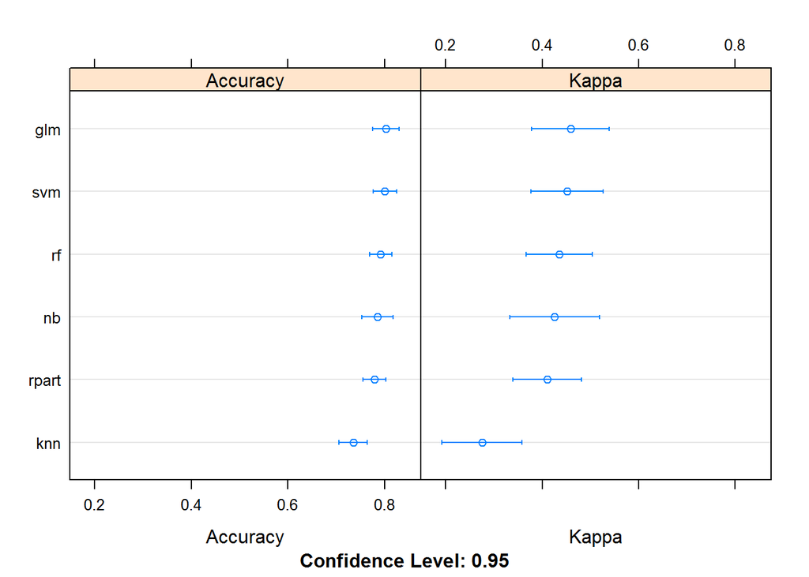

```r
dotplot(results)
```

```r
modelCor(results)
```

```
##             glm        rf        knn     rpart        nb        svm
## glm   1.0000000 0.8311409 0.30374254 0.7457863 0.8425353 0.82650379
## rf    0.8311409 1.0000000 0.27356158 0.8503043 0.5999950 0.64783932
## knn   0.3037425 0.2735616 1.00000000 0.2603457 0.3807172 0.06301477
## rpart 0.7457863 0.8503043 0.26034570 1.0000000 0.5013949 0.49585654
## nb    0.8425353 0.5999950 0.38071720 0.5013949 1.0000000 0.77525584
## svm   0.8265038 0.6478393 0.06301477 0.4958565 0.7752558 1.00000000
```

### Let’s try ensembling to see if performance enhances

High level steps are:

1. Train the individual base layer models on training data.
2. Predict using each base layer model for training data and test data. (One key thing to note here is that out of fold predictions are used while predicting for the training data).
3. Now train the top layer model again on the predictions of the bottom layer models that has been made on the training data.
4. Finally, predict using the top layer model with the predictions of bottom layer models that has been made for testing data.

### Step 1) is already done above.

Let’s combine different models to form an ensemble.

Two of the key principles for selecting the models:

- The individual models fulfill particular accuracy criteria.
- The model predictions of various individual models are not highly correlated with the predictions of other models.

Let’s try svm and knn (as correlation is least)

### Step 2) Predict using each base layer model for training data and test data.

```r
#Predicting the out of fold prediction probabilities for training data

trainSet1$OOF_pred_svm<-model_svm$pred$Y[order(model_svm$pred$rowIndex)]
trainSet1$OOF_pred_knn<-model_knn$pred$Y[order(model_knn$pred$rowIndex)]



#Predicting probabilities for the test data

testSet1$OOF_pred_svm<-predict(model_svm,testSet1[predictors],type='prob')$Y
testSet1$OOF_pred_knn<-predict(model_knn,testSet1[predictors],type='prob')$Y
```

### Step 3) Now train the top layer model again on the predictions of the bottom layer models that has been made on the training data.

```r
#Predictors for top layer models
predictors_top <- c('OOF_pred_svm','OOF_pred_knn')

set.seed(101)

#GBM as top layer model (Gradient Boosting)
model_gbm <- train(trainSet1[,predictors_top],trainSet1[,outcomeName],method='gbm',trControl=fitControl,verbose = FALSE)
#verbose: logical. Should R report extra information on progress? If TRUE then report progress
model_gbm
```

```
## Stochastic Gradient Boosting
##
## 461 samples
##   2 predictor
##   2 classes: 'N', 'Y'
##
## No pre-processing
## Resampling: Cross-Validated (10 fold)
## Summary of sample sizes: 414, 415, 416, 414, 414, 415, ...
## Resampling results across tuning parameters:
##
##   interaction.depth  n.trees  Accuracy   Kappa
##   1                   50      0.7984891  0.4474965
##   1                  100      0.7984891  0.4474965
##   1                  150      0.7984891  0.4474965
##   2                   50      0.7984891  0.4474965
##   2                  100      0.7963593  0.4469579
##   2                  150      0.7940909  0.4470576
##   3                   50      0.7963131  0.4449383
##   3                  100      0.7897872  0.4385508
##   3                  150      0.7919611  0.4497680
##
## Tuning parameter 'shrinkage' was held constant at a value of 0.1
##
## Tuning parameter 'n.minobsinnode' was held constant at a value of 10
## Accuracy was used to select the optimal model using  the largest value.
## The final values used for the model were n.trees = 50, interaction.depth
##  = 1, shrinkage = 0.1 and n.minobsinnode = 10.
```

### Step 4: Finally, predict using the top layer model with the predictions of bottom layer models that has been made for testing data

```r
#predict using GBM top layer model
testSet1$gbm_stacked<-predict(model_gbm,testSet1[,predictors_top])
```

```r
#check the accuracy
confusionMatrix(testSet1$gbm_stacked,testSet1$Loan_Status,positive = 'Y')
```

```
## Confusion Matrix and Statistics
##
##           Reference
## Prediction   N   Y
##          N  24   2
##          Y  24 103
##
##                Accuracy : 0.8301
##                  95% CI : (0.761, 0.8859)
##     No Information Rate : 0.6863
##     P-Value [Acc > NIR] : 4.049e-05
##
##                   Kappa : 0.5493
##  Mcnemar's Test P-Value : 3.814e-05
##
##             Sensitivity : 0.9810
##             Specificity : 0.5000
##          Pos Pred Value : 0.8110
##          Neg Pred Value : 0.9231
##              Prevalence : 0.6863
##          Detection Rate : 0.6732
##    Detection Prevalence : 0.8301
##       Balanced Accuracy : 0.7405
##
##        'Positive' Class : Y
##
```

Can infer that:

```r
#Training the random forest model

set.seed(101)
#using 10-fold cross validation

model_rf_tune<-train(trainSet1[,predictors],trainSet1[,outcomeName],method='rf',trControl=fitControl,ntree=951)
model_rf_tune
```

```
## Random Forest
##
## 461 samples
##  11 predictor
##   2 classes: 'N', 'Y'
##
## No pre-processing
## Resampling: Cross-Validated (10 fold)
## Summary of sample sizes: 414, 415, 416, 414, 414, 415, ...
## Resampling results across tuning parameters:
##
##   mtry  Accuracy   Kappa
##    2    0.7939963  0.4399727
##    6    0.7614760  0.3758997
##   11    0.7614760  0.3825663
##
## Accuracy was used to select the optimal model using  the largest value.
## The final value used for the model was mtry = 2.
```

```r
#Predicting using random forest model
predict_model_rf_tune<-predict(model_rf_tune,testSet1[,predictors])

#Checking the accuracy of the random forest model
confusionMatrix(predict_model_rf_tune,testSet1[,outcomeName],positive = 'Y')
```

```
## Confusion Matrix and Statistics
##
##           Reference
## Prediction  N  Y
##          N 28  6
##          Y 20 99
##
##                Accuracy : 0.8301
##                  95% CI : (0.761, 0.8859)
##     No Information Rate : 0.6863
##     P-Value [Acc > NIR] : 4.049e-05
##
##                   Kappa : 0.5714
##  Mcnemar's Test P-Value : 0.01079
##
##             Sensitivity : 0.9429
##             Specificity : 0.5833
##          Pos Pred Value : 0.8319
##          Neg Pred Value : 0.8235
##              Prevalence : 0.6863
##          Detection Rate : 0.6471
##    Detection Prevalence : 0.7778
##       Balanced Accuracy : 0.7631
##
##        'Positive' Class : Y
##
```

Can infer that:

- The accuracy improved very slightly only (from 0.8235 to 0.8301)
- Specificity also increased from 0.56 to 0.58

### Use the best model to try to improve specificty (This decision should be taken in concurrence with bank goals)

```r
t12<-predict(model_rf_tune,testSet1[,predictors],type='prob')$Y
t12 <- ifelse(t12>0.622,'Y','N')
confusionMatrix(t12,testSet1$Loan_Status,positive = 'Y')
```

```
## Confusion Matrix and Statistics
##
##           Reference
## Prediction  N  Y
##          N 32 22
##          Y 16 83
##
##                Accuracy : 0.7516
##                  95% CI : (0.6754, 0.8179)
##     No Information Rate : 0.6863
##     P-Value [Acc > NIR] : 0.04677
##
##                   Kappa : 0.4421
##  Mcnemar's Test P-Value : 0.41730
##
##             Sensitivity : 0.7905
##             Specificity : 0.6667
##          Pos Pred Value : 0.8384
##          Neg Pred Value : 0.5926
##              Prevalence : 0.6863
##          Detection Rate : 0.5425
##    Detection Prevalence : 0.6471
##       Balanced Accuracy : 0.7286
##
##        'Positive' Class : Y
##
```

Can infer that:

- On setting the threshold as 0.622 instead of 0.5, Specificity increased from 0.58 to 0.66. However, there is fall in accuracy and Sensitivity.

### Some interesting observations - Credit History as main variable

```r
LoanStat <- ifelse(loan_train1$Loan_Status=='Y',1,0)
table(Loan_Status=LoanStat)
```

```
## Loan_Status
##   0   1
## 192 422
```

```r
table(Credit_History=loan_train1$Credit_History)
```

```
## Credit_History
##   0   1
##  89 525
```

```r
confusionMatrix(loan_train1$Credit_History,LoanStat,positive = '1')
```

```
## Confusion Matrix and Statistics
##
##           Reference
## Prediction   0   1
##          0  82   7
##          1 110 415
##
##                Accuracy : 0.8094
##                  95% CI : (0.7761, 0.8398)
##     No Information Rate : 0.6873
##     P-Value [Acc > NIR] : 6.062e-12
##
##                   Kappa : 0.4808
##  Mcnemar's Test P-Value : < 2.2e-16
##
##             Sensitivity : 0.9834
##             Specificity : 0.4271
##          Pos Pred Value : 0.7905
##          Neg Pred Value : 0.9213
##              Prevalence : 0.6873
##          Detection Rate : 0.6759
##    Detection Prevalence : 0.8550
##       Balanced Accuracy : 0.7052
##
##        'Positive' Class : 1
##
```

Can infer that:

- If we simply say credit history of 1(good), approve the loan and credit history of 0(not good) then don’t approve the loan, the accuracy of such a inference is 0.80947 which is quite good but got poor specificty of 0.42
- This is the main field having very high predictive power.

### Testing the “Test data” on the best model

```r
# Loading the Test data

loan_test_ori <- read.csv('test_loan.csv',na.strings = c('NA',''))

loan_test <- loan_test_ori

miss(loan_test)
```

```
##
## The columns having missing values are:
##  Gender : 11
##  Dependents : 10
##  Self_Employed : 23
##  LoanAmount : 5
##  Loan_Amount_Term : 6
##  Credit_History : 29
##
## The number of rows with missing values are: 78
## The proportion of missing values is: 0.21
```

```r
cat('\n')
```

```r
# removing loan_ID

loan_test_Loan_ID <- loan_test[,1]
loan_test <- loan_test[-1]

# making the variables as factor

loan_test$Credit_History <- as.factor(loan_test$Credit_History)
loan_test$Loan_Amount_Term <- as.factor(loan_test$Loan_Amount_Term)

# missing values imputation

loan_test <- kNN(loan_test,variable=c('Gender','Dependents','Self_Employed','LoanAmount','Loan_Amount_Term','Credit_History'),k=19,numFun = weightedMean,weightDist=TRUE)

loan_test <- loan_test[-c(12:17)]

cat('\n########After missing values imputation#########\n')
```

```
##
## ########After missing values imputation#########
```

```r
miss(loan_test)
```

```
##
## The columns having missing values are:
##
## The number of rows with missing values are: 0
## The proportion of missing values is: 0
```

```r
cat('\n\n')
```

```r
# coverting and normalising the data

loan_test[,c(1:5,9,10,11)] <- sapply(loan_test[,c(1:5,9,10,11)], function(x) as.numeric(x))

loan_test[,c(6:9)] <- scale(loan_test[,c(6:9)],center=TRUE,scale=TRUE)

# Now the data is ready for applying best model
# Predicting using tuned random forest model

loan_test_ori$Loan_Status <- predict(model_rf_tune,loan_test[,predictors])

# The final dataset with loan status updated (Y - approve the loan, N - reject the loan)

table(loan_status=loan_test_ori$Loan_Status)
```

```
## loan_status
##   N   Y
##  62 305
```

Can infer that:

- Out of the total 367 applicants, the loan can be approved to 305 applicants and can be rejected for 62 cases.
- The accuracy of this prediction is 83% (model accuracy)